# Proyecto Bellabeat

Damian L. Angelucci

2025-07-31

# Introducción

Este informe presenta los resultados de un análisis realizado sobre los patrones de sueño y actividad de usuarios de dispositivos de bienestar, como los que ofrece Bellabeat. Se utilizaron datos recolectados sobre pasos diarios, tiempo en cama y minutos dormidos. El objetivo fue identificar tendencias útiles para generar recomendaciones accionables para la empresa Bellabeat y ayudar a sus usuarios a mejorar su descanso.

# Objetivos del Análisis

- Investigar los patrones de sueño según el día de la semana.
- Analizar la eficiencia del sueño (minutos dormidos vs tiempo en cama).
- Evaluar la relación entre nivel de actividad física y cantidad de sueño.
- Generar recomendaciones para Bellabeat basadas en los hallazgos.

## Carga de las tablas dailyActivity & sleepDay:

```r
daily <- read_csv("dailyActivity_merged.csv")
sleep <- read_csv("sleepDay_merged.csv")
```

## Tablas cargadas

```r
# Tabla daily
glimpse(daily)
```

```
## Rows: 940
## Columns: 15
## $ Id                       <dbl> 1503960366, 1503960366, 1503960366, 150396036…
## $ ActivityDate             <chr> "4/12/2016", "4/13/2016", "4/14/2016", "4/15/…
## $ TotalSteps               <dbl> 13162, 10735, 10460, 9762, 12669, 9705, 13019…
## $ TotalDistance            <dbl> 8.50, 6.97, 6.74, 6.28, 8.16, 6.48, 8.59, 9.8…
## $ TrackerDistance          <dbl> 8.50, 6.97, 6.74, 6.28, 8.16, 6.48, 8.59, 9.8…
## $ LoggedActivitiesDistance <dbl> 0, 0, 0, 0, 0, 0, 0, 0, 0, 0, 0, 0, 0, 0, 0, …
## $ VeryActiveDistance       <dbl> 1.88, 1.57, 2.44, 2.14, 2.71, 3.19, 3.25, 3.5…
## $ ModeratelyActiveDistance <dbl> 0.55, 0.69, 0.40, 1.26, 0.41, 0.78, 0.64, 1.3…
## $ LightActiveDistance      <dbl> 6.06, 4.71, 3.91, 2.83, 5.04, 2.51, 4.71, 5.0…
## $ SedentaryActiveDistance  <dbl> 0, 0, 0, 0, 0, 0, 0, 0, 0, 0, 0, 0, 0, 0, 0, …
## $ VeryActiveMinutes        <dbl> 25, 21, 30, 29, 36, 38, 42, 50, 28, 19, 66, 4…
## $ FairlyActiveMinutes      <dbl> 13, 19, 11, 34, 10, 20, 16, 31, 12, 8, 27, 21…
## $ LightlyActiveMinutes     <dbl> 328, 217, 181, 209, 221, 164, 233, 264, 205, …
## $ SedentaryMinutes         <dbl> 728, 776, 1218, 726, 773, 539, 1149, 775, 818…
## $ Calories                 <dbl> 1985, 1797, 1776, 1745, 1863, 1728, 1921, 203…
```

```r
# Tabla sleep
glimpse(sleep)
```

```
## Rows: 413
## Columns: 5
## $ Id                 <dbl> 1503960366, 1503960366, 1503960366, 1503960366, 150…
## $ SleepDay           <chr> "4/12/2016 12:00:00 AM", "4/13/2016 12:00:00 AM", "…
## $ TotalSleepRecords  <dbl> 1, 2, 1, 2, 1, 1, 1, 1, 1, 1, 1, 1, 1, 1, 1, 1, 1, …
## $ TotalMinutesAsleep <dbl> 327, 384, 412, 340, 700, 304, 360, 325, 361, 430, 2…
## $ TotalTimeInBed     <dbl> 346, 407, 442, 367, 712, 320, 377, 364, 384, 449, 3…
```

# Limpieza y procesamiento de los datos

## Formateo de fechas con mdy: configura fecha en yyyy-mm-dd

```r
daily <- daily |> mutate(activity_date = mdy(ActivityDate))
# Tabla daily
glimpse(daily)
```

```
## Rows: 940
## Columns: 16
## $ Id                       <dbl> 1503960366, 1503960366, 1503960366, 150396036…
## $ ActivityDate             <chr> "4/12/2016", "4/13/2016", "4/14/2016", "4/15/…
## $ TotalSteps               <dbl> 13162, 10735, 10460, 9762, 12669, 9705, 13019…
## $ TotalDistance            <dbl> 8.50, 6.97, 6.74, 6.28, 8.16, 6.48, 8.59, 9.8…
## $ TrackerDistance          <dbl> 8.50, 6.97, 6.74, 6.28, 8.16, 6.48, 8.59, 9.8…
## $ LoggedActivitiesDistance <dbl> 0, 0, 0, 0, 0, 0, 0, 0, 0, 0, 0, 0, 0, 0, 0, …
## $ VeryActiveDistance       <dbl> 1.88, 1.57, 2.44, 2.14, 2.71, 3.19, 3.25, 3.5…
## $ ModeratelyActiveDistance <dbl> 0.55, 0.69, 0.40, 1.26, 0.41, 0.78, 0.64, 1.3…
## $ LightActiveDistance      <dbl> 6.06, 4.71, 3.91, 2.83, 5.04, 2.51, 4.71, 5.0…
## $ SedentaryActiveDistance  <dbl> 0, 0, 0, 0, 0, 0, 0, 0, 0, 0, 0, 0, 0, 0, 0, …
## $ VeryActiveMinutes        <dbl> 25, 21, 30, 29, 36, 38, 42, 50, 28, 19, 66, 4…
## $ FairlyActiveMinutes      <dbl> 13, 19, 11, 34, 10, 20, 16, 31, 12, 8, 27, 21…
## $ LightlyActiveMinutes     <dbl> 328, 217, 181, 209, 221, 164, 233, 264, 205, …
## $ SedentaryMinutes         <dbl> 728, 776, 1218, 726, 773, 539, 1149, 775, 818…
## $ Calories                 <dbl> 1985, 1797, 1776, 1745, 1863, 1728, 1921, 203…
## $ activity_date            <date> 2016-04-12, 2016-04-13, 2016-04-14, 2016-04-…
```

```r
sleep <- mutate(sleep, sleep_day = sub(" .*", "", SleepDay))
sleep <- mutate(sleep, sleep_day = mdy(sleep_day))
# Tabla sleep
glimpse(sleep)
```

```
## Rows: 413
## Columns: 6
## $ Id                 <dbl> 1503960366, 1503960366, 1503960366, 1503960366, 150…
## $ SleepDay           <chr> "4/12/2016 12:00:00 AM", "4/13/2016 12:00:00 AM", "…
## $ TotalSleepRecords  <dbl> 1, 2, 1, 2, 1, 1, 1, 1, 1, 1, 1, 1, 1, 1, 1, 1, 1, …
## $ TotalMinutesAsleep <dbl> 327, 384, 412, 340, 700, 304, 360, 325, 361, 430, 2…
## $ TotalTimeInBed     <dbl> 346, 407, 442, 367, 712, 320, 377, 364, 384, 449, 3…
## $ sleep_day          <date> 2016-04-12, 2016-04-13, 2016-04-15, 2016-04-16, 20…
```

## Concatenación de id y la fecha en una nueva columna id_date

```r
daily <- daily |> mutate(id_date = paste(Id, activity_date))
# Tabla daily con id_date
glimpse(daily)
```

```
## Rows: 940
## Columns: 17
## $ Id                       <dbl> 1503960366, 1503960366, 1503960366, 150396036…
## $ ActivityDate             <chr> "4/12/2016", "4/13/2016", "4/14/2016", "4/15/…
## $ TotalSteps               <dbl> 13162, 10735, 10460, 9762, 12669, 9705, 13019…
## $ TotalDistance            <dbl> 8.50, 6.97, 6.74, 6.28, 8.16, 6.48, 8.59, 9.8…
## $ TrackerDistance          <dbl> 8.50, 6.97, 6.74, 6.28, 8.16, 6.48, 8.59, 9.8…
## $ LoggedActivitiesDistance <dbl> 0, 0, 0, 0, 0, 0, 0, 0, 0, 0, 0, 0, 0, 0, 0, …
## $ VeryActiveDistance       <dbl> 1.88, 1.57, 2.44, 2.14, 2.71, 3.19, 3.25, 3.5…
## $ ModeratelyActiveDistance <dbl> 0.55, 0.69, 0.40, 1.26, 0.41, 0.78, 0.64, 1.3…
## $ LightActiveDistance      <dbl> 6.06, 4.71, 3.91, 2.83, 5.04, 2.51, 4.71, 5.0…
## $ SedentaryActiveDistance  <dbl> 0, 0, 0, 0, 0, 0, 0, 0, 0, 0, 0, 0, 0, 0, 0, …
## $ VeryActiveMinutes        <dbl> 25, 21, 30, 29, 36, 38, 42, 50, 28, 19, 66, 4…
## $ FairlyActiveMinutes      <dbl> 13, 19, 11, 34, 10, 20, 16, 31, 12, 8, 27, 21…
## $ LightlyActiveMinutes     <dbl> 328, 217, 181, 209, 221, 164, 233, 264, 205, …
## $ SedentaryMinutes         <dbl> 728, 776, 1218, 726, 773, 539, 1149, 775, 818…
## $ Calories                 <dbl> 1985, 1797, 1776, 1745, 1863, 1728, 1921, 203…
## $ activity_date            <date> 2016-04-12, 2016-04-13, 2016-04-14, 2016-04-…
## $ id_date                  <chr> "1503960366 2016-04-12", "1503960366 2016-04-…
```

```r
sleep <- sleep |> mutate(id_date = paste(Id, sleep_day))
# Tabla sleep con id_date
glimpse(sleep)
```

```
## Rows: 413
## Columns: 7
## $ Id                 <dbl> 1503960366, 1503960366, 1503960366, 1503960366, 150…
## $ SleepDay           <chr> "4/12/2016 12:00:00 AM", "4/13/2016 12:00:00 AM", "…
## $ TotalSleepRecords  <dbl> 1, 2, 1, 2, 1, 1, 1, 1, 1, 1, 1, 1, 1, 1, 1, 1, 1, …
## $ TotalMinutesAsleep <dbl> 327, 384, 412, 340, 700, 304, 360, 325, 361, 430, 2…
## $ TotalTimeInBed     <dbl> 346, 407, 442, 367, 712, 320, 377, 364, 384, 449, 3…
## $ sleep_day          <date> 2016-04-12, 2016-04-13, 2016-04-15, 2016-04-16, 20…
## $ id_date            <chr> "1503960366 2016-04-12", "1503960366 2016-04-13", "…
```

## Unión de tablas daily-sleep por id_date

```r
daily_merged <- left_join(daily,sleep |>
  select(id_date, TotalMinutesAsleep, TotalTimeInBed),by = "id_date")
# Tabla daily_merged
glimpse(daily_merged)
```

```
## Rows: 943
## Columns: 19
## $ Id                       <dbl> 1503960366, 1503960366, 1503960366, 150396036…
## $ ActivityDate             <chr> "4/12/2016", "4/13/2016", "4/14/2016", "4/15/…
## $ TotalSteps               <dbl> 13162, 10735, 10460, 9762, 12669, 9705, 13019…
## $ TotalDistance            <dbl> 8.50, 6.97, 6.74, 6.28, 8.16, 6.48, 8.59, 9.8…
## $ TrackerDistance          <dbl> 8.50, 6.97, 6.74, 6.28, 8.16, 6.48, 8.59, 9.8…
## $ LoggedActivitiesDistance <dbl> 0, 0, 0, 0, 0, 0, 0, 0, 0, 0, 0, 0, 0, 0, 0, …
## $ VeryActiveDistance       <dbl> 1.88, 1.57, 2.44, 2.14, 2.71, 3.19, 3.25, 3.5…
## $ ModeratelyActiveDistance <dbl> 0.55, 0.69, 0.40, 1.26, 0.41, 0.78, 0.64, 1.3…
## $ LightActiveDistance      <dbl> 6.06, 4.71, 3.91, 2.83, 5.04, 2.51, 4.71, 5.0…
## $ SedentaryActiveDistance  <dbl> 0, 0, 0, 0, 0, 0, 0, 0, 0, 0, 0, 0, 0, 0, 0, …
## $ VeryActiveMinutes        <dbl> 25, 21, 30, 29, 36, 38, 42, 50, 28, 19, 66, 4…
## $ FairlyActiveMinutes      <dbl> 13, 19, 11, 34, 10, 20, 16, 31, 12, 8, 27, 21…
## $ LightlyActiveMinutes     <dbl> 328, 217, 181, 209, 221, 164, 233, 264, 205, …
## $ SedentaryMinutes         <dbl> 728, 776, 1218, 726, 773, 539, 1149, 775, 818…
## $ Calories                 <dbl> 1985, 1797, 1776, 1745, 1863, 1728, 1921, 203…
## $ activity_date            <date> 2016-04-12, 2016-04-13, 2016-04-14, 2016-04-…
## $ id_date                  <chr> "1503960366 2016-04-12", "1503960366 2016-04-…
## $ TotalMinutesAsleep       <dbl> 327, 384, NA, 412, 340, 700, NA, 304, 360, 32…
## $ TotalTimeInBed           <dbl> 346, 407, NA, 442, 367, 712, NA, 320, 377, 36…
```

```r
# Nuevos campos en daily_merged
daily_merged <- daily_merged |>
  mutate(
    avg_Eficiencia = TotalMinutesAsleep / TotalTimeInBed,
    dia_semana = wday(activity_date, label= TRUE, abbr= FALSE),
    nivelActividad = case_when(
      TotalSteps >= 10000 ~ "Alto",
      TotalSteps >= 5000 & TotalSteps <10000 ~ "Moderado",
      TotalSteps < 5000 ~ "Bajo"
    )
  )

# Tabla daily_merged creada
glimpse(daily_merged)
```

```
## Rows: 943
## Columns: 22
## $ Id                       <dbl> 1503960366, 1503960366, 1503960366, 150396036…
## $ ActivityDate             <chr> "4/12/2016", "4/13/2016", "4/14/2016", "4/15/…
## $ TotalSteps               <dbl> 13162, 10735, 10460, 9762, 12669, 9705, 13019…
## $ TotalDistance            <dbl> 8.50, 6.97, 6.74, 6.28, 8.16, 6.48, 8.59, 9.8…
## $ TrackerDistance          <dbl> 8.50, 6.97, 6.74, 6.28, 8.16, 6.48, 8.59, 9.8…
## $ LoggedActivitiesDistance <dbl> 0, 0, 0, 0, 0, 0, 0, 0, 0, 0, 0, 0, 0, 0, 0, …
## $ VeryActiveDistance       <dbl> 1.88, 1.57, 2.44, 2.14, 2.71, 3.19, 3.25, 3.5…
## $ ModeratelyActiveDistance <dbl> 0.55, 0.69, 0.40, 1.26, 0.41, 0.78, 0.64, 1.3…
## $ LightActiveDistance      <dbl> 6.06, 4.71, 3.91, 2.83, 5.04, 2.51, 4.71, 5.0…
## $ SedentaryActiveDistance  <dbl> 0, 0, 0, 0, 0, 0, 0, 0, 0, 0, 0, 0, 0, 0, 0, …
## $ VeryActiveMinutes        <dbl> 25, 21, 30, 29, 36, 38, 42, 50, 28, 19, 66, 4…
## $ FairlyActiveMinutes      <dbl> 13, 19, 11, 34, 10, 20, 16, 31, 12, 8, 27, 21…
## $ LightlyActiveMinutes     <dbl> 328, 217, 181, 209, 221, 164, 233, 264, 205, …
## $ SedentaryMinutes         <dbl> 728, 776, 1218, 726, 773, 539, 1149, 775, 818…
## $ Calories                 <dbl> 1985, 1797, 1776, 1745, 1863, 1728, 1921, 203…
## $ activity_date            <date> 2016-04-12, 2016-04-13, 2016-04-14, 2016-04-…
## $ id_date                  <chr> "1503960366 2016-04-12", "1503960366 2016-04-…
## $ TotalMinutesAsleep       <dbl> 327, 384, NA, 412, 340, 700, NA, 304, 360, 32…
## $ TotalTimeInBed           <dbl> 346, 407, NA, 442, 367, 712, NA, 320, 377, 36…
## $ avg_Eficiencia           <dbl> 0.9450867, 0.9434889, NA, 0.9321267, 0.926430…
## $ dia_semana               <ord> martes, miércoles, jueves, viernes, sábado, d…
## $ nivelActividad           <chr> "Alto", "Alto", "Alto", "Moderado", "Alto", "…
```

# Análisis y Visualización de datos

## A) TotalMinutesAsleep vs DiaSemana

```r
avg_sueño_dia <- daily_merged %>%
  group_by(dia_semana) %>%
    summarise(avg_TotalMinutesAsleep = mean(TotalMinutesAsleep, na.rm = TRUE))

# Tabla avg_sueño_dia
glimpse(avg_sueño_dia)
```

```
## Rows: 7
## Columns: 2
## $ dia_semana             <ord> domingo, lunes, martes, miércoles, jueves, vier…
## $ avg_TotalMinutesAsleep <dbl> 452.7455, 418.8298, 404.5385, 434.6818, 402.369…
```

## Gráfica TotalMinutesAsleep vs DiaSemana

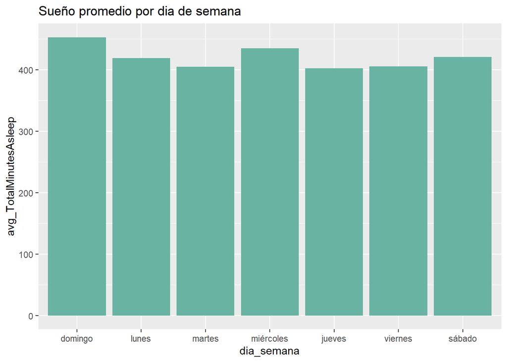

```r
ggplot(avg_sueño_dia, aes(x= dia_semana, y= avg_TotalMinutesAsleep)) +
geom_col(fill= "#69b3a2") +
labs(title = "Sueño promedio por dia de semana")
```

Se observó que los domingos y los miércoles son los días en que los usuarios duermen más en promedio. Insigth: Los fines de semana permiten mayor descanso, aunque no siempre con buena calidad.

## B) EficienciaProm vs DiaSemana

```r
avg_eficiencia_dia <- daily_merged %>%
  group_by(dia_semana) %>%
    summarise(Eficiencia = mean(avg_Eficiencia, na.rm = TRUE))

# Tabla avg_eficiencia_dia
glimpse(avg_eficiencia_dia)
```

```
## Rows: 7
## Columns: 2
## $ dia_semana <ord> domingo, lunes, martes, miércoles, jueves, viernes, sábado
## $ Eficiencia <dbl> 0.9050898, 0.9206540, 0.9109481, 0.9212852, 0.9231239, 0.92…
```

## Gráfica EficienciaProm vs DiaSemana

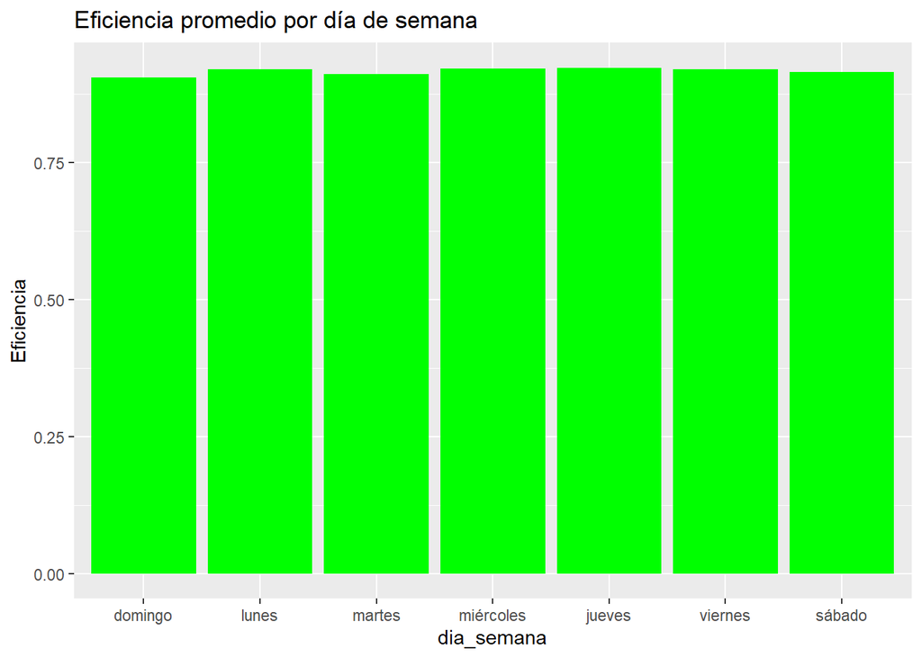

```r
ggplot(avg_eficiencia_dia, aes(x= dia_semana, y= Eficiencia)) +
geom_col(fill= "#00FF00") +
labs(title= "Eficiencia promedio por día de semana")
```

Los días con más sueño (como el domingo) no son los más eficientes. La eficiencia es mayor de miércoles a viernes. Insight: Durante la semana laboral, los usuarios tienden a dormir menos tiempo pero de forma más eficiente.

```r
avg_nivel_actividad <- daily_merged %>%
  group_by(nivelActividad) %>%
    summarise(avg_Sueño = mean(TotalMinutesAsleep, na.rm = TRUE))

# Tabla avg_nivel_actividad
glimpse(avg_nivel_actividad)
```

```
## Rows: 3
## Columns: 2
## $ nivelActividad <chr> "Alto", "Bajo", "Moderado"
## $ avg_Sueño      <dbl> 396.7545, 454.2917, 422.4667
```

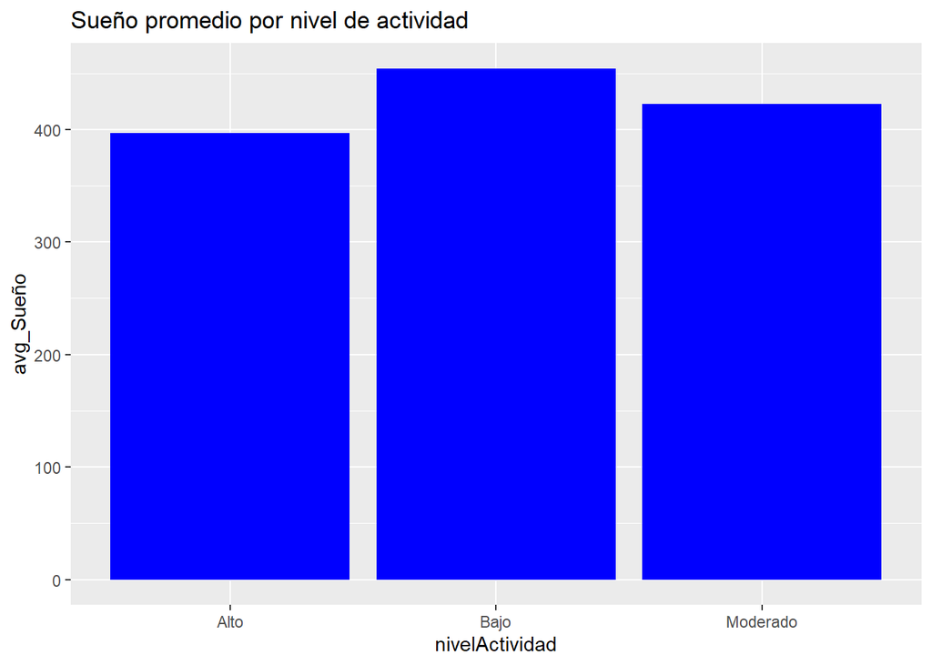

```r
ggplot(avg_nivel_actividad, aes(x= nivelActividad, y= avg_Sueño)) +
geom_col(fill="#0000FF") +
labs(title= "Sueño promedio por nivel de actividad")
```

El análisis mostró que los niveles de actividad física más altos no están relacionados con más sueño. En algunos casos, el sueño disminiye. Insight: Los usuarios más activos podrían tener rutinas más intensas y dormir menos.

## D) Eficiencia prom vs Sueño promedio

```r
eficiencia_sueño <- daily_merged %>%
  group_by(dia_semana) %>%
      summarise(
          avg_Sueño = mean(TotalMinutesAsleep, na.rm = TRUE),
          Eficiencia = mean(avg_Eficiencia, na.rm = TRUE)
      )

# Tabla eficiencia_sueño
glimpse(eficiencia_sueño)
```

```
## Rows: 7
## Columns: 3
## $ dia_semana <ord> domingo, lunes, martes, miércoles, jueves, viernes, sábado
## $ avg_Sueño  <dbl> 452.7455, 418.8298, 404.5385, 434.6818, 402.3692, 405.4211,…
## $ Eficiencia <dbl> 0.9050898, 0.9206540, 0.9109481, 0.9212852, 0.9231239, 0.92…
```

## Gráfica Eficiencia prom vs Sueño promedio

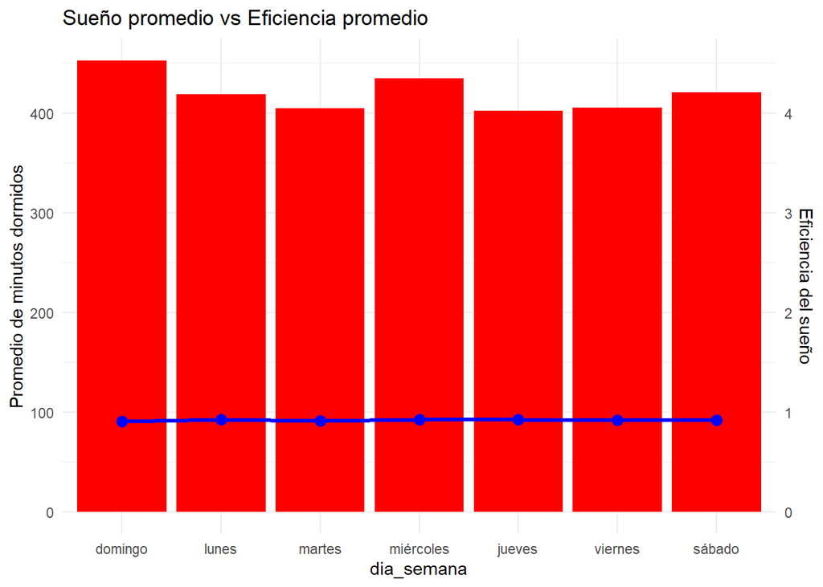

```r
ggplot(eficiencia_sueño, aes(x= dia_semana)) +
geom_col(aes(y= avg_Sueño), fill="#FF0000") +
geom_line(aes(y= Eficiencia * 100, group=1), color= "blue", size= 1.2)+
geom_point(aes(y= Eficiencia * 100), color= "blue", size= 3) +
scale_y_continuous(
    name= "Promedio de minutos dormidos",
    sec.axis= sec_axis(~./100, name= "Eficiencia del sueño")
) +
labs(title="Sueño promedio vs Eficiencia promedio") +
theme_minimal()
```

Al comparar la duración de sueño y eficiencia del sueño por día, se observó que mayor cantidad de minutos de sueño no implica mejor descanso. Insight: El domingo se duerme más, pero con menor eficiencia; jueves y viernes se duerme menos, pero con mayor calidad.

## Recomendaciones para Bellabeat

1. Enfocar métricas y notificaciones en la eficiencia del suelo, no solo en la cantidad de minutos.
2. Agregar recomendaciones personalizadas según el día de la semana (Por ejemplo, fines de semana).
3. Detectar patrones individuales de baja eficiencia y proponer acciones concretas.
4. Incentivar rutinas de sueño regulares para mejorar la calidad del descanso.

# Conclusiones

El comportamiento del sueño no depende solamente de la cantidad de horas dormidas, sino también del contexto diario, la rutina y la estructura semanal. Bellabeat tiene la oportunidad de desarrollar funciones que ayuden a sus usuarios a mejorar no solo cuanto duermen, sino cómo duermen, enfocándose en la eficiencia y la personalización.